# Homework 5: Mixed Effects Models

Gera

11/07/2019

We first started by looking at the data. Here we are comparing growth metrics by lineage as shown in Figure 1. We can see a consistency in growth both dry mass per plant and total branch count. The Hyb being the lineage with the most growth followed by ACP and then the CON lineage. But in the Density M2 metric we see the opposite, the CON was the lineage with the most growth followed by ACP then the HYB lineage.

We then followed by finding a fit linear model to test whether environmental parameters (Dissolved_O2, Temperature, Conductivity, Alkalinity, or pH) are important covariates. We explored using AIC, which compares log-likelihoods of successive models. Table 1 shows the AIC output of dry mass per plant. From the result we can see a consistency of Figure 1 through the coefficients. The Hyb having the highest coefficient, ACP not showing, possibly meaning not a factor or 0 ,and Con being negative. Table 2 measuring the total branches per plant , shows a similar result with a much higher Hyb coefficient. Measuring density M2 showed the opposite result which is consistent to Figure 1. The higher the positive coefficient predicts a positive change. According to this result using environmental parameters, Hyb lineage of variable-leaf watermilfoil grows more aggressively than the parental lineages in dry mass per plant and total branch count but not in density M2.

We then added a random effect for Lake in our final models. Table 4 shows the final model for dry mass per plant from Table 1 and showed a little difference in coefficients but did not show a different result. Table 5 shows total branch count and Table 6 shows density M2 with both having the random effect for Lake to the final models. Both did not show different result as well. In addition, we tested if the random model improved the fit of the model using a model comparison method. There was not much of a difference. For example, in dry mass per plant, the AIC for the linear model was 417.17 and the added random effect was 418.28 not much of a difference. For total branches per plant and density per M2, we saw a similar trend, not much of a difference. But if we have to decide the better model, than the linear model is better due to having a lower AIC than the model with the random effect of lake. In Figure 2 we illustrate through plots for dry mass per plant, total branch count and density M2 the result of variation of random effect for Lake. Through the plots we can see that almost all interval contains zero indicating that the lake random effect does not affect the results.

**Figure 1: Lineages vs Growth Metrics**

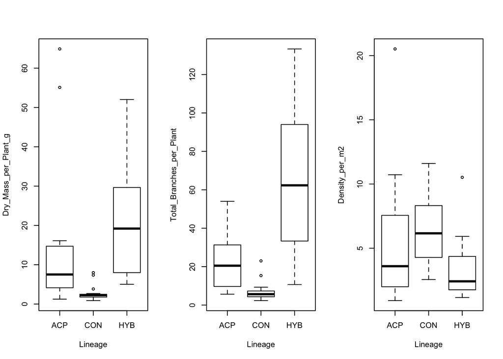

**Table 1: Dry_Mass_per_Plant_g AIC**

```
## Start:  AIC=263.97
## Dry_Mass_per_Plant_g ~ Lineage + Dissolved_O2 + Temperature +
##     Conductivity + Alkalinity + pH
##
##                Df Sum of Sq    RSS    AIC
## - Conductivity  1    111.97 5441.6 263.09
## - Temperature   1    127.02 5456.7 263.24
## <none>                      5329.7 263.97
## - pH            1    583.41 5913.1 267.58
## - Lineage       2    911.12 6240.8 268.49
## - Dissolved_O2  1    836.52 6166.2 269.84
## - Alkalinity    1   1122.32 6452.0 272.29
##
## Step:  AIC=263.09
## Dry_Mass_per_Plant_g ~ Lineage + Dissolved_O2 + Temperature +
##     Alkalinity + pH
##
##                Df Sum of Sq    RSS    AIC
## - Temperature   1     84.00 5525.6 261.92
## <none>                      5441.6 263.09
## - pH            1    543.45 5985.1 266.23
## - Lineage       2    969.33 6411.0 267.95
## - Dissolved_O2  1    811.79 6253.4 268.60
## - Alkalinity    1   1946.30 7387.9 277.61
##
## Step:  AIC=261.92
## Dry_Mass_per_Plant_g ~ Lineage + Dissolved_O2 + Alkalinity +
##     pH
##
##                Df Sum of Sq    RSS    AIC
## <none>                      5525.6 261.92
## - Lineage       2   1075.41 6601.0 267.52
## - Dissolved_O2  1    975.81 6501.4 268.70
## - pH            1   1056.02 6581.7 269.37
## - Alkalinity    1   2267.69 7793.3 278.49
```

```
##
## Call:
## lm(formula = Dry_Mass_per_Plant_g ~ Lineage + Dissolved_O2 +
##     Alkalinity + pH, data = dataset)
##
## Coefficients:
##  (Intercept)    LineageCON    LineageHYB  Dissolved_O2    Alkalinity
##      45.5948       -7.9220        3.4683        0.4812        0.3931
##           pH
##     -11.7698
```

**Table 2: Total_Branches_per_Plant AIC**

```
## Start:  AIC=321.68
## Total_Branches_per_Plant ~ Lineage + Dissolved_O2 + Temperature +
##     Conductivity + Alkalinity + pH
##
##                Df Sum of Sq   RSS    AIC
## - Conductivity  1     244.2 15762 320.52
## <none>                      15518 321.68
## - Temperature   1     913.2 16431 322.77
## - pH            1     934.5 16452 322.84
## - Dissolved_O2  1    2332.7 17851 327.24
## - Alkalinity    1    3104.4 18622 329.53
## - Lineage       2   18569.3 34087 360.18
##
## Step:  AIC=320.52
## Total_Branches_per_Plant ~ Lineage + Dissolved_O2 + Temperature +
##     Alkalinity + pH
##
##                Df Sum of Sq   RSS    AIC
## <none>                      15762 320.52
## - Temperature   1     753.6 16516 321.05
## - pH            1     858.9 16621 321.39
## - Dissolved_O2  1    2272.1 18034 325.80
## - Alkalinity    1    5819.2 21581 335.49
## - Lineage       2   18591.0 34353 358.60
```

```
##
## Call:
## lm(formula = Total_Branches_per_Plant ~ Lineage + Dissolved_O2 +
##     Temperature + Alkalinity + pH, data = dataset)
##
## Coefficients:
##  (Intercept)    LineageCON    LineageHYB  Dissolved_O2   Temperature
##      61.6704       -6.3024       38.9434        0.7523       -1.4615
##   Alkalinity            pH
##       0.6480      -12.3300
```

**Table 3: Density_per_m2 AIC**

```
## Start:  AIC=142.65
## Density_per_m2 ~ Lineage + Dissolved_O2 + Temperature + Conductivity +
##     Alkalinity + pH
##
##                Df Sum of Sq    RSS    AIC
## - Alkalinity    1     0.577 564.22 140.71
## - Temperature   1     0.897 564.54 140.74
## - Dissolved_O2  1     3.994 567.64 141.03
## - Conductivity  1     8.494 572.14 141.46
## - pH            1    16.087 579.73 142.17
## - Lineage       2    40.937 604.58 142.44
## <none>                      563.64 142.65
##
## Step:  AIC=140.71
## Density_per_m2 ~ Lineage + Dissolved_O2 + Temperature + Conductivity +
##     pH
##
##                Df Sum of Sq    RSS    AIC
## - Temperature   1     0.979 565.20 138.80
## - Dissolved_O2  1     3.984 568.20 139.09
## - pH            1    15.541 579.76 140.18
## <none>                      564.22 140.71
## - Lineage       2    43.980 608.20 140.76
## - Conductivity  1    39.925 604.14 142.40
##
## Step:  AIC=138.8
## Density_per_m2 ~ Lineage + Dissolved_O2 + Conductivity + pH
##
##                Df Sum of Sq    RSS    AIC
## - Dissolved_O2  1     3.360 568.56 137.12
## - pH            1    15.717 580.91 138.28
## - Lineage       2    43.397 608.59 138.80
## <none>                      565.20 138.80
## - Conductivity  1    40.049 605.25 140.50
##
## Step:  AIC=137.12
## Density_per_m2 ~ Lineage + Conductivity + pH
##
##                Df Sum of Sq    RSS    AIC
## - pH            1    12.379 580.94 136.28
## <none>                      568.56 137.12
## - Lineage       2    51.606 620.16 137.81
## - Conductivity  1    44.456 613.01 139.19
##
## Step:  AIC=136.29
## Density_per_m2 ~ Lineage + Conductivity
##
##                Df Sum of Sq    RSS    AIC
## <none>                      580.94 136.28
## - Lineage       2    60.407 641.34 137.63
## - Conductivity  1    47.350 628.29 138.52
```

```
##
## Call:
## lm(formula = Density_per_m2 ~ Lineage + Conductivity, data = dataset)
##
## Coefficients:
##  (Intercept)    LineageCON    LineageHYB  Conductivity
##      7.11476       1.27630      -1.37346      -0.02442
```

**Table 4: Dry_Mass_per_Plant_g final model with random effect for Lake**

```
## Linear mixed model fit by REML ['lmerMod']
## Formula: Dry_Mass_per_Plant_g ~ Lineage + Dissolved_O2 + Alkalinity +
##     pH + (1 | Lake)
##    Data: dataset
## REML criterion at convergence: 390.5731
## Random effects:
##  Groups   Name        Std.Dev.
##  Lake     (Intercept) 5.477
##  Residual             9.567
## Number of obs: 54, groups:  Lake, 17
## Fixed Effects:
##  (Intercept)    LineageCON    LineageHYB  Dissolved_O2    Alkalinity
##      47.2127       -8.2642        3.3959        0.4196        0.4046
##           pH
##     -11.1822
```

**Table 5:Total_Branches_per_Plant final model with random effect for Lake**

```
## Linear mixed model fit by REML ['lmerMod']
## Formula:
## Total_Branches_per_Plant ~ Lineage + Dissolved_O2 + Temperature +
##     Alkalinity + pH + (1 | Lake)
##    Data: dataset
## REML criterion at convergence: 439.7618
## Random effects:
##  Groups   Name        Std.Dev.
##  Lake     (Intercept)  9.034
##  Residual             16.621
## Number of obs: 54, groups:  Lake, 17
## Fixed Effects:
##  (Intercept)    LineageCON    LineageHYB  Dissolved_O2   Temperature
##      49.0467       -7.7968       35.0567        0.8252       -1.3119
##   Alkalinity            pH
##       0.6970      -12.0860
```

**Table 6: Density_per_m2 final model with random effect for Lake**

```
## Linear mixed model fit by REML ['lmerMod']
## Formula: Density_per_m2 ~ Lineage + Conductivity + (1 | Lake)
##    Data: dataset
## REML criterion at convergence: 282.2707
## Random effects:
##  Groups   Name        Std.Dev.
##  Lake     (Intercept) 1.693
##  Residual             3.049
## Number of obs: 54, groups:  Lake, 17
## Fixed Effects:
##  (Intercept)    LineageCON    LineageHYB  Conductivity
##       7.0672        1.2816       -1.2557       -0.0239
```

**Figure 2: Three growth metrics with random effect as a source of variation plot**

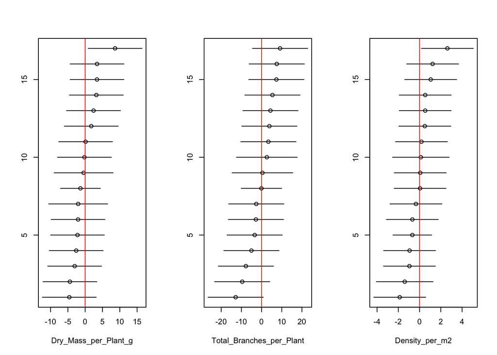

[output not shown]